# Prediction of the transmission mode giving better mileage per gallon for cars in mtcars dataset

Piyush

Monday, January 20, 2015

```r
library(datasets)
library(ggplot2)
data(mtcars)

dimen<-dim(mtcars)
#Seeing a summary of the dataset
head(mtcars,7)
```

```
##                    mpg cyl disp  hp drat    wt  qsec vs am gear carb
## Mazda RX4         21.0   6  160 110 3.90 2.620 16.46  0  1    4    4
## Mazda RX4 Wag     21.0   6  160 110 3.90 2.875 17.02  0  1    4    4
## Datsun 710        22.8   4  108  93 3.85 2.320 18.61  1  1    4    1
## Hornet 4 Drive    21.4   6  258 110 3.08 3.215 19.44  1  0    3    1
## Hornet Sportabout 18.7   8  360 175 3.15 3.440 17.02  0  0    3    2
## Valiant           18.1   6  225 105 2.76 3.460 20.22  1  0    3    1
## Duster 360        14.3   8  360 245 3.21 3.570 15.84  0  0    3    4
```

**This data set consists of 32 observations (car models) and 11 parameters for evaluating the performance of each observation**

**Section 1.** In this section we shall see if there is a relationship at all between ‘mpg’ and the predictor variables. We shall test this by fitting a linear model and testing the p value of the F statistic

```r
fit0<-lm(mpg~., data=mtcars)
result0<-summary(fit0)$fstatistic
p <- pf(result0[1],result0[2],result0[3],lower.tail=F)
pValue<-summary(fit0)$coeff
pValue<-pValue[order(pValue[,4]),]
pValue
```

```
##             Estimate Std. Error t value Pr(>|t|)
## wt          -3.71530    1.89441 -1.9612  0.06325
## am           2.52023    2.05665  1.2254  0.23399
## qsec         0.82104    0.73084  1.1234  0.27394
## hp          -0.02148    0.02177 -0.9868  0.33496
## disp         0.01334    0.01786  0.7468  0.46349
## (Intercept) 12.30337   18.71788  0.6573  0.51812
## drat         0.78711    1.63537  0.4813  0.63528
## gear         0.65541    1.49326  0.4389  0.66521
## carb        -0.19942    0.82875 -0.2406  0.81218
## vs           0.31776    2.10451  0.1510  0.88142
## cyl         -0.11144    1.04502 -0.1066  0.91609
```

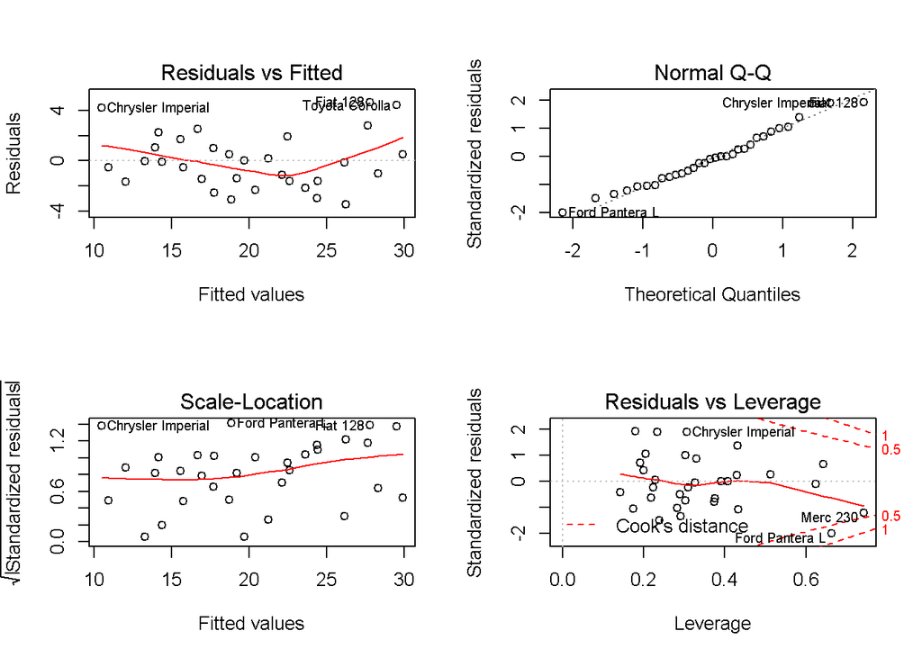

```r
par(mfrow=c(2,2))
plot(fit0)
```

**Conclusion 1:** The p value associated with the F statistic is 3.7932 × 10<sup>-7</sup>. Since the p value is low, we can say that a relationship exists.

Also, there is a strong pattern observed in the plot of residuals vs fitted values, assuming linearity in the data. Presence of this strong pattern suggests non-linearity in the relationship.

We also observe that the most significant p value is for wt. However since our variable of concern is ‘am’, we shall start building our model with that and move on with the others.

**Section 2.** In this section we shall see try to understand the nature of the relationship that the response mileage per gallon holds with each of the respective quantitative predictor variables thorugh feature plots of response vs predictor

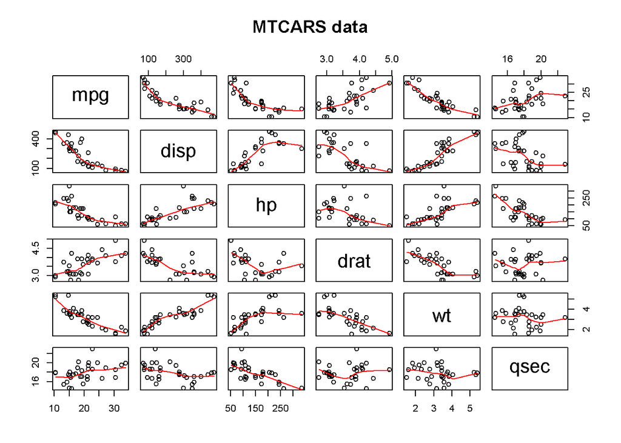

```r
pairs(mtcars[c(1,3:7)], panel = panel.smooth, main = "MTCARS data")
```

**Conclusion 2:** The plot clearly shows a non linear (mostly quadratic) association for the predictors ‘disp’ and ‘hp’. However, the predictors ‘wt’, ‘drat’ and ‘qsec’ can well approximated by a least squares line.

**Section 3.** In this section , we will do a nested model testing for seeing which of the predictors are significant.We will carry out the test based on the p-Value for the t-statistic of the individual predictors in the model that was made with all the predictors.

**3.1.** Our first block includes variables for the weight, disp, drat and horsepower.

```r
pValue<-pValue[-2,]
fit1<-lm(mpg~factor(am), data=mtcars)
fit2<-update(fit1,mpg~factor(am)+wt)
fit3<-update(fit2,mpg~factor(am)+wt+qsec)
fit4<-update(fit3,mpg~factor(am)+wt+qsec+hp+I(hp^2))
fit5<-update(fit4,mpg~factor(am)+wt+qsec+hp+I(hp^2)+disp+I(disp^2))
fit6<-update(fit5,mpg~factor(am)+wt+qsec+hp+I(hp^2)+disp+I(disp^2)+drat)
fit7<-update(fit6,mpg~factor(am)+wt+qsec+hp+I(hp^2)+disp+I(disp^2)+drat+factor(gear))
result1<-anova(fit1,fit2,fit3,fit4,fit5,fit6,fit7)
result1
```

```
## Analysis of Variance Table
##
## Model 1: mpg ~ factor(am)
## Model 2: mpg ~ factor(am) + wt
## Model 3: mpg ~ factor(am) + wt + qsec
## Model 4: mpg ~ factor(am) + wt + qsec + hp + I(hp^2)
## Model 5: mpg ~ factor(am) + wt + qsec + hp + I(hp^2) + disp + I(disp^2)
## Model 6: mpg ~ factor(am) + wt + qsec + hp + I(hp^2) + disp + I(disp^2) +
##     drat
## Model 7: mpg ~ factor(am) + wt + qsec + hp + I(hp^2) + disp + I(disp^2) +
##     drat + factor(gear)
##   Res.Df RSS Df Sum of Sq     F  Pr(>F)
## 1     30 721
## 2     29 278  1       443 79.02 1.5e-08 ***
## 3     28 169  1       109 19.47 0.00024 ***
## 4     26 149  2        20  1.77 0.19450
## 5     24 121  2        29  2.55 0.10162
## 6     23 120  1         1  0.10 0.76054
## 7     21 118  2         3  0.24 0.79059
## ---
## Signif. codes:  0 '***' 0.001 '**' 0.01 '*' 0.05 '.' 0.1 ' ' 1
```

**Conclusion:** If we include am variable, it makes sense to include variable ‘wt’ since the p value associated with the second model w.r.t. to the first is 1.4607 × 10<sup>-8</sup>. Also, if we include variables ‘wt’ and ‘am’, it makes sense to include ‘qsec’ variable since the p value for the third model with respect to the second model is 2.4257 × 10<sup>-4</sup>. However, it does not make sense to include variables for ‘hp’, ‘disp’, ‘drat’ and ‘gear’ because the pvalues associated with thier models are statistically insignificant

**3.2.** The second block will test the inclusion the variables ‘carb’, ‘vs’ and ‘cyl’. Also, the model on which it will be done will be exempted from ‘hp’, ‘disp’, ‘drat’ and ‘gear’.

```r
fit8<-lm(mpg~factor(am)+wt+qsec, data=mtcars)
fit9<-update(fit8,mpg~factor(am)+wt+qsec+factor(carb))
fit10<-update(fit9,mpg~factor(am)+wt+qsec+factor(carb)+vs)
fit11<-update(fit10,mpg~factor(am)+wt+qsec+factor(carb)+vs+factor(cyl))
result2<-anova(fit8,fit9,fit10,fit11)
result2
```

```
## Analysis of Variance Table
##
## Model 1: mpg ~ factor(am) + wt + qsec
## Model 2: mpg ~ factor(am) + wt + qsec + factor(carb)
## Model 3: mpg ~ factor(am) + wt + qsec + factor(carb) + vs
## Model 4: mpg ~ factor(am) + wt + qsec + factor(carb) + vs + factor(cyl)
##   Res.Df RSS Df Sum of Sq    F Pr(>F)
## 1     28 169
## 2     23 158  5     11.00 0.29   0.91
## 3     22 157  1      1.24 0.16   0.69
## 4     20 154  2      3.55 0.23   0.80
```

**Conclusion:** Clearly, we see that the p-values ofr the models are not significant. So, we will not take the following models.

**Section 4.** Now that we have our model of interest, we will look create a summary of the coefficents for the variables of our concern.

```r
fit12<-lm(mpg~factor(am)+wt+qsec, data=mtcars)
coeff<-summary(fit12)$coeff
coeff
```

```
##             Estimate Std. Error t value  Pr(>|t|)
## (Intercept)    9.618     6.9596   1.382 1.779e-01
## factor(am)1    2.936     1.4109   2.081 4.672e-02
## wt            -3.917     0.7112  -5.507 6.953e-06
## qsec           1.226     0.2887   4.247 2.162e-04
```

**APPENDIX**

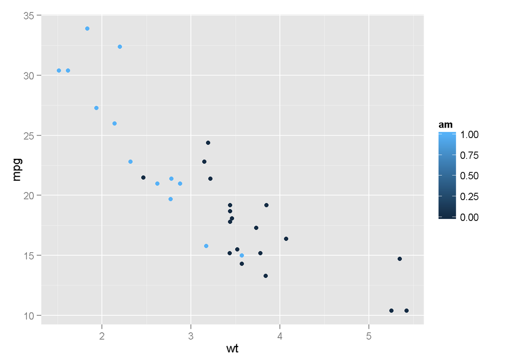

```r
qplot(wt,mpg,data=mtcars,col=am)
```

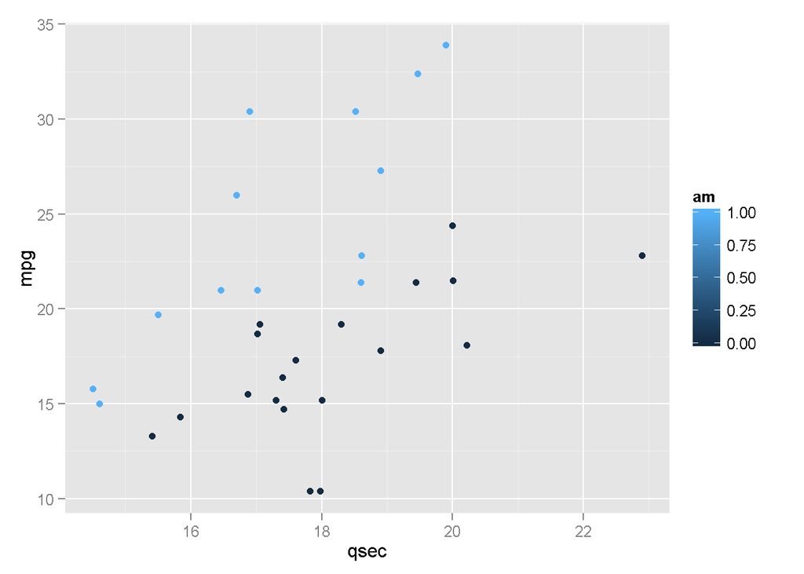

```r
qplot(qsec,mpg,data=mtcars,col=am)
```

**Conclusion:** However, if do do an individual plot of wt on mpg, and colour the data points by variable ‘am’, we see that manual transmission seems to be associated with higher values of mpg. Same results are seen when we try to analyze the plot of qsec vs mpg. This phenomenon can be explained as confounding.